# N uptake calculations

Zhang Zhenglin

# Background

Nitrogen (N) is the currency of agronomic systems, making crop N uptake a key response variable in many research projects. The research group in the beginning of 2024 realised that N uptake calculations often did not account for moisture of samples that were at differring stages. This could lead to inaccurate computations of N upatake.

Telha Rehman performed empirical analysis, showing that samples had the following corresponding moisture contents:

Oven dry: 1.9% Ambient straw: 8.27% Ambient grain: 9.76%

The basic idea of this script - which can be adapted for everyone’s individual project - is that computation involving two or more weights need to be corrected for moisture. In this script, Zhang has chosen to correct all weights to the “ambient” values.

# Read and check data

```r
#read data
master = read_excel('SIF_NRate_NUptake_Base_Dataframe.xlsx', sheet = 1)

master$Microbalance_sample_Weight_mg <- as.numeric(master$Microbalance_sample_Weight_mg)

str(master)
```

```
tibble [336 × 12] (S3: tbl_df/tbl/data.frame)
 $ SampleID                             : chr [1:336] "701-MG" "702-MG" "703-MG" "704-MG" ...
 $ SIF_N_µg                             : num [1:336] 85.8 56.2 65.3 41.8 73.9 ...
 $ Microbalance_sample_Weight_mg        : num [1:336] 5.5 4.94 4.98 4.72 5.23 ...
 $ Oven_dry_Sample_Weight_g             : num [1:336] 5264105 9981691 7902092 8450992 5596197 ...
 $ Area_harvested_m2                    : num [1:336] 10000 10000 10000 10000 10000 10000 10000 10000 10000 10000 ...
 $ Oven_dry_sample_moisture_percent     : num [1:336] 14 14 14 14 14 14 14 14 14 14 ...
 $ Microbalance_ambient_moisture_percent: num [1:336] 9.76 9.76 9.76 9.76 9.76 9.76 9.76 9.76 9.76 9.76 ...
 $ Stage                                : chr [1:336] "Maturity_Grain" "Maturity_Grain" "Maturity_Grain" "Maturity_Grain" ...
 $ Treatment                            : chr [1:336] "FR" "FR" "FR" "FR" ...
 $ Blk                                  : num [1:336] 7 7 7 7 7 7 7 7 7 7 ...
 $ Topdress                             : chr [1:336] "NIL" "NIL" "NIL" "NIL" ...
 $ Year                                 : num [1:336] 2023 2023 2023 2023 2023 ...
```

```r
table(master$Stage)
```

```
       Heading Maturity_Grain Maturity_Straw             PI
            48            132            132             24
```

```r
table(master$Treatment)
```

```
CR FR
36 36
```

```r
table(master$Topdress)
```

```
  0   1 NIL
 96  72 168
```

```r
table(master$Blk)
```

```
 7  8  9
24 24 24
```

```r
table(master$Year)
```

```
2021 2022 2023
 132  132   72
```

```r
#dataset looks good and complete
```

# N uptake calculations

There were samples taken at different physiological stages for Zhang’s study. If you have samples taken before maturity, please pay close attention to the choices made below. If all samples were taken at maturity, then focus on how samples at maturity can be handled.

Specifically for this data set, maturity samples were harvested (1) by hand and (2) by a combine.

For (1) harvest by hand oven dry weights were used. For (2) combine harvest, 14% moisture was used in combination with harvest index was used to calculate N uptake.

N uptake for PI and 50% heading are determined from non-segregated plant parts. i.e. the whole plant was ground to a powder together and is representative of the crop’s N uptake. As most of the tissue here is vegetative, we assume that ambient moisture is the same as straw (8.27%)

N uptake for maturity are determined from separated plant parts - grain and straw. This step calculates N present in grain and straw, but do not sum them yet. Moisture for is 8.27% for straw and 9.76% for grains.

Dry samples were measured after stabilizing in the oven for a period of time (>24hrs) and was measured to be 1.9%.

For 2023, we directly used yield. Grain yield was reported at 14%

For 2023, grain was harvested by combine. A sub-sample was taken to evaluate N uptake. Harvest index (HI) was quantified from this subsample and used to estimate straw weight.

For for information on calculating weights based on moisture: https://edis.ifas.ufl.edu/publication/AG442

```r
#Getting N concentration: g N per g of microbalanced sample (g/g)

master$N_per_g_microbalanced_sample <- ((master$SIF_N_µg)/(master$Microbalance_sample_Weight_mg))/1000

#Dry sample weight is at 1.9% for 2021 and 2022 samples, 14% for 2023 samples. These values were pre populated in the excel
#We need to correct the weight for ambient moisture where the samples were measured into tin capsules during microbalancing

master$Ambient_Sample_Weight_g <- master$Oven_dry_Sample_Weight_g*((100-master$Oven_dry_sample_moisture_percent)/(100-master$Microbalance_ambient_moisture_percent))

str(master)
```

```
tibble [336 × 14] (S3: tbl_df/tbl/data.frame)
 $ SampleID                             : chr [1:336] "701-MG" "702-MG" "703-MG" "704-MG" ...
 $ SIF_N_µg                             : num [1:336] 85.8 56.2 65.3 41.8 73.9 ...
 $ Microbalance_sample_Weight_mg        : num [1:336] 5.5 4.94 4.98 4.72 5.23 ...
 $ Oven_dry_Sample_Weight_g             : num [1:336] 5264105 9981691 7902092 8450992 5596197 ...
 $ Area_harvested_m2                    : num [1:336] 10000 10000 10000 10000 10000 10000 10000 10000 10000 10000 ...
 $ Oven_dry_sample_moisture_percent     : num [1:336] 14 14 14 14 14 14 14 14 14 14 ...
 $ Microbalance_ambient_moisture_percent: num [1:336] 9.76 9.76 9.76 9.76 9.76 9.76 9.76 9.76 9.76 9.76 ...
 $ Stage                                : chr [1:336] "Maturity_Grain" "Maturity_Grain" "Maturity_Grain" "Maturity_Grain" ...
 $ Treatment                            : chr [1:336] "FR" "FR" "FR" "FR" ...
 $ Blk                                  : num [1:336] 7 7 7 7 7 7 7 7 7 7 ...
 $ Topdress                             : chr [1:336] "NIL" "NIL" "NIL" "NIL" ...
 $ Year                                 : num [1:336] 2023 2023 2023 2023 2023 ...
 $ N_per_g_microbalanced_sample         : num [1:336] 0.0156 0.01139 0.01311 0.00885 0.01412 ...
 $ Ambient_Sample_Weight_g              : num [1:336] 5016767 9512693 7530806 8053916 5333255 ...
```

```r
#Total N uptake = g N per g of microbalanced sample (g/g)*total sample weight (g)/area harvested (m2)
#then scale from g/m2 to kg/ha

master$N_total_kgha <- ((master$N_per_g_microbalanced_sample*master$Ambient_Sample_Weight_g)/1000) * (10000/master$Area_harvested_m2)

str(master)
```

```
tibble [336 × 15] (S3: tbl_df/tbl/data.frame)
 $ SampleID                             : chr [1:336] "701-MG" "702-MG" "703-MG" "704-MG" ...
 $ SIF_N_µg                             : num [1:336] 85.8 56.2 65.3 41.8 73.9 ...
 $ Microbalance_sample_Weight_mg        : num [1:336] 5.5 4.94 4.98 4.72 5.23 ...
 $ Oven_dry_Sample_Weight_g             : num [1:336] 5264105 9981691 7902092 8450992 5596197 ...
 $ Area_harvested_m2                    : num [1:336] 10000 10000 10000 10000 10000 10000 10000 10000 10000 10000 ...
 $ Oven_dry_sample_moisture_percent     : num [1:336] 14 14 14 14 14 14 14 14 14 14 ...
 $ Microbalance_ambient_moisture_percent: num [1:336] 9.76 9.76 9.76 9.76 9.76 9.76 9.76 9.76 9.76 9.76 ...
 $ Stage                                : chr [1:336] "Maturity_Grain" "Maturity_Grain" "Maturity_Grain" "Maturity_Grain" ...
 $ Treatment                            : chr [1:336] "FR" "FR" "FR" "FR" ...
 $ Blk                                  : num [1:336] 7 7 7 7 7 7 7 7 7 7 ...
 $ Topdress                             : chr [1:336] "NIL" "NIL" "NIL" "NIL" ...
 $ Year                                 : num [1:336] 2023 2023 2023 2023 2023 ...
 $ N_per_g_microbalanced_sample         : num [1:336] 0.0156 0.01139 0.01311 0.00885 0.01412 ...
 $ Ambient_Sample_Weight_g              : num [1:336] 5016767 9512693 7530806 8053916 5333255 ...
 $ N_total_kgha                         : num [1:336] 78.3 108.4 98.7 71.3 75.3 ...
```

# Getting the maturity summed values: summing N uptake values of straw and grain

```r
#separate into straw and grains for summing
maturity_straw <- master %>%  filter(Stage == ("Maturity_Straw"))
maturity_grain <- master %>%  filter(Stage == ("Maturity_Grain"))


#maturity_straw <-
 # maturity_straw %>%
  #filter(Year != 2021) %>%
 # mutate(Plot = substr(SampleID, 1, 3))

#maturity_grain <-
 # maturity_straw %>%
  #filter(Year != 2021) %>%
  #mutate(Plot = substr(SampleID, 1, 3))

as.numeric(maturity_straw$Plot) - as.numeric(maturity_grain$Plot)
```

```
numeric(0)
```

```r
#Create dataframe for maturity total N uptake
maturity_summed <- as.data.frame(rbind(master[1:36,], master[109:156,], master[241:288,]))
# just so we can keep the other columns
maturity_summed$Stage <- "Maturity"

#sum grain and straw into one maturity total N uptake dataframe
maturity_summed$N_total_kgha <- maturity_straw$N_total_kgha+maturity_grain$N_total_kgha

str(maturity_summed)
```

```
'data.frame':   132 obs. of  15 variables:
 $ SampleID                             : chr  "701-MG" "702-MG" "703-MG" "704-MG" ...
 $ SIF_N_µg                             : num  85.8 56.2 65.3 41.8 73.9 ...
 $ Microbalance_sample_Weight_mg        : num  5.5 4.94 4.98 4.72 5.23 ...
 $ Oven_dry_Sample_Weight_g             : num  5264105 9981691 7902092 8450992 5596197 ...
 $ Area_harvested_m2                    : num  10000 10000 10000 10000 10000 10000 10000 10000 10000 10000 ...
 $ Oven_dry_sample_moisture_percent     : num  14 14 14 14 14 14 14 14 14 14 ...
 $ Microbalance_ambient_moisture_percent: num  9.76 9.76 9.76 9.76 9.76 9.76 9.76 9.76 9.76 9.76 ...
 $ Stage                                : chr  "Maturity" "Maturity" "Maturity" "Maturity" ...
 $ Treatment                            : chr  "FR" "FR" "FR" "FR" ...
 $ Blk                                  : num  7 7 7 7 7 7 7 7 7 7 ...
 $ Topdress                             : chr  "NIL" "NIL" "NIL" "NIL" ...
 $ Year                                 : num  2023 2023 2023 2023 2023 ...
 $ N_per_g_microbalanced_sample         : num  0.0156 0.01139 0.01311 0.00885 0.01412 ...
 $ Ambient_Sample_Weight_g              : num  5016767 9512693 7530806 8053916 5333255 ...
 $ N_total_kgha                         : num  163.4 165.2 175.4 95.6 151.9 ...
```

# Bind everything back again - this is such a pain in the rear end. Add in plots and Nrates

```r
#Well I was a clown when I started the PhD, so I named everything for excel LOL.
#Because name formatting was different by year, I split the dataframe by year and wrangle it as needed

# extract PI and Heading N uptake values
master_maturity_summed <- rbind(master[73:108,], master[205:240,], maturity_summed)

#add in plot and treatments

master_maturity_summed_2021 <-
  master_maturity_summed %>%
  filter(Year == 2021) %>%
  mutate(Plot = substr(SampleID, 5, 7)) %>%
  mutate(Treatment = case_when(
  Plot %in% c("101", "102", "103", "104", "105", "106",
              "201", "202", "203", "204", "205", "206",
              "301", "302", "303", "304", "305", "306") ~ "FR",
  Plot %in% c("107", "108", "109", "110", "111", "112",
              "207", "208", "209", "210", "211", "212",
              "307", "308", "309", "310", "311", "312") ~ "CR",
  TRUE ~ "Other" # This line handles cases where plot is not listed
  ))

master_maturity_summed_others <-
  master_maturity_summed %>%
  filter(Year != 2021) %>%
  mutate(Plot = substr(SampleID, 1, 3)) %>%
  mutate(Treatment = case_when(
  Plot %in% c("401", "402", "403", "404", "405", "406",
              "501", "502", "503", "504", "505", "506",
              "601", "602", "603", "604", "605", "606",
              "701", "702", "703", "704", "705", "706",
              "801", "802", "803", "804", "805", "806",
              "901", "902", "903", "904", "905", "906") ~ "FR",
  Plot %in% c("407", "408", "409", "410", "411", "412",
              "507", "508", "509", "510", "511", "512",
              "607", "608", "609", "610", "611", "612",
              "707", "708", "709", "710", "711", "712",
              "807", "808", "809", "810", "811", "812",
              "907", "908", "909", "910", "911", "912") ~ "CR",
  TRUE ~ "Other" # This line handles cases where plot is not listed
  ))

master_maturity_summed_clean <- rbind(master_maturity_summed_2021, master_maturity_summed_others)

# add in blk, days

master_maturity_summed_clean <- master_maturity_summed_clean %>%
  mutate(Blk = substr(Plot, 1, 1))%>%
  mutate(Days = case_when(
  Stage %in% c("PI") ~ "47",
  Stage %in% c("Heading") ~ "82",
  Stage %in% c("Maturity") ~ "134",
  TRUE ~ "Other" # This line handles cases where plot is not listed
  ))

# read in Nrate reference file

#clean the data frame to have one plot match with one Nrate
Nrate_ref <- read_excel("D:/Academics/UC Davis/School Work/Linquist Lab/Data/R stats/Agronomic paper/Yield/master_yields.xlsx", sheet = 1) %>%  mutate(Plot = substr(Plot, 1, 3)) %>% mutate(Nrate_kgha = Nrate) %>%  distinct(Plot, .keep_all = TRUE)

# put in the Nrate for all the plots
master_maturity_summed_clean <- master_maturity_summed_clean %>%
  left_join(Nrate_ref %>% select(Plot, Nrate_kgha), by = "Plot")
```

# Export dataframe

```r
for_export <- master_maturity_summed_clean %>%
                         select(SampleID,
                                Plot,
                                Stage,
                                Treatment,
                                Year,
                                Topdress,
                                N_total_kgha,
                                Blk,
                                Days,
                                Nrate_kgha)

head(master_maturity_summed_clean)
```

| SampleID | SIF_N_µg | Microbalance_sample_Weight_mg | Oven_dry_Sample_Weight_g | Area_harvested_m2 | Oven_dry_sample_moisture_percent | Microbalance_ambient_moisture_percent | Stage | Treatment | Blk | Topdress | Year | N_per_g_microbalanced_sample | Ambient_Sample_Weight_g | N_total_kgha | Plot | Days | Nrate_kgha |
| --- | --- | --- | --- | --- | --- | --- | --- | --- | --- | --- | --- | --- | --- | --- | --- | --- | --- |
| RES 104 | 79.32 | 5.392 | 286.09 | 1 | 1.9 | 8.27 | PI | FR | 1 | 0 | 2021 | 0.01471068 | 305.9569 | 45.00835 | 104 | 47 | 0 |
| RES 201 | 98.95 | 5.279 | 269.99 | 1 | 1.9 | 8.27 | PI | FR | 2 | 0 | 2021 | 0.01874408 | 288.7389 | 54.12145 | 201 | 47 | 0 |
| RES 304 | 74.40 | 5.254 | 341.09 | 1 | 1.9 | 8.27 | PI | FR | 3 | 0 | 2021 | 0.01416064 | 364.7763 | 51.65466 | 304 | 47 | 0 |
| RES 112 | 79.56 | 5.499 | 231.19 | 1 | 1.9 | 8.27 | PI | CR | 1 | 0 | 2021 | 0.01446809 | 247.2445 | 35.77155 | 112 | 47 | 0 |
| RES 212 | 73.27 | 5.017 | 243.29 | 1 | 1.9 | 8.27 | PI | CR | 2 | 0 | 2021 | 0.01460435 | 260.1848 | 37.99828 | 212 | 47 | 0 |
| RES 310 | 61.94 | 4.845 | 234.59 | 1 | 1.9 | 8.27 | PI | CR | 3 | 0 | 2021 | 0.01278431 | 250.8806 | 32.07337 | 310 | 47 | 0 |

```r
write_xlsx(for_export, "N_uptake_Maturity_Summed_Clean.xlsx")
```

# Filtering for N uptake over time

```r
N_over_time <- master_maturity_summed_clean %>%
               filter(Topdress == '0') %>%
               select(SampleID,
                                Plot,
                                Stage,
                                Treatment,
                                Year,
                                Topdress,
                                N_total_kgha,
                                Blk,
                                Days,
                                Nrate_kgha)

write_xlsx(N_over_time, "D:/Academics/UC Davis/School Work/Linquist Lab/Data/R stats/Agronomic paper/N uptake/N uptake over time - 2021_22/N_uptake_over_time.xlsx")
```

# Plot a small visualization to make sure things generally look good

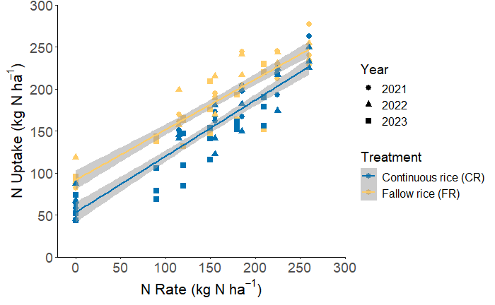

```r
Nrate_trial <- master_maturity_summed_clean %>%
  #filter(Year != 2023) %>%
  filter(Topdress!=1) %>%
  filter(Stage=="Maturity") %>%
  mutate(Year= as.factor(Year))
  #group_by(Treatment, Nrate_kgha, Year) %>%
  #mutate(N_total_kgha_se = sd(N_total_kgha)/sqrt(3)) %>%
  #summarise(N_total_kgha = mean(N_total_kgha),
  #N_total_kgha_se = mean(N_total_kgha_se))


all_Nuptake_graph <-
ggplot(Nrate_trial, aes(x=Nrate_kgha, y=N_total_kgha, color=Treatment,shape = Year))+
  geom_point(size=2.5)+
  geom_smooth(aes(group = Treatment),method = lm, alpha=0.5)+
  scale_color_manual(values=c("#0072B2","#FFCC66"), name = "Treatment", labels = c("Continuous rice (CR)", "Fallow rice (FR)"))+
  scale_x_continuous(name=expression("N Rate (kg N ha"^{-1}*")"), limits = c(-20, 300), expand = c(0, 0), breaks = seq(0, 300, by = 50))+
  scale_y_continuous(name=expression("N Uptake (kg N ha"^{-1}*")"), limits = c(0, 300), expand = c(0, 0), breaks = seq(0, 300, by = 50))+
  #geom_errorbar(aes(ymin=N_total_kgha-N_total_kgha_se, ymax=N_total_kgha+N_total_kgha_se), width=3,position=position_dodge(0.5))+
  #geom_vline(xintercept = c(41, 50, 78, 84, 121, 136), linetype = "dashed", color = "black") +
  theme_classic()+
  theme(axis.text = element_text(size = 14), axis.title = element_text(size=16))+
  theme(legend.text = element_text(size = 12),legend.title = element_text(size = 14))+
  theme(plot.title = element_text(hjust = 0.5, size = 15))


ggsave(filename = "all_Nuptake_graph.png",  # Include the file extension here
       plot = all_Nuptake_graph,            # Specify the plot
       path = "D:/Academics/UC Davis/School Work/Linquist Lab/Data/R stats/Agronomic paper/Figures",
       dpi = 400,
       height = 30, width = 30, units = "cm")

all_Nuptake_graph
```

```r
#plots seem to make sense. Lets proceed with more fun things!!!!
```